```python
__nbid__ = '0083'
__author__ = 'Brian Merino <brian.merino@noirlab.edu>'
__version__ = '20260615' # yyyymmdd; version datestamp of this notebook
__keywords__ = ['flamingos-2','Gemini','longslit','nova','DRAGONS']
```

# Gemini Flamingos-2 JH and HK Longslit Point Source reduction using DRAGONS Python API

## Public archival data from f2ils_tutorial - GS-2022A-DD-105 (U Sco)

#### adapted from https://dragons.readthedocs.io/projects/f2ls-drtutorial/en/v4.2.1/ex1_f2ls_JHHK_api.html

- Goals
- Summary
- Disclaimers and attribution
- Imports and setup
- Prepare the working directory
- Set up the DRAGONS logger
- About the dataset
- Downloading data for reduction
- Create File Lists
- Create Master Dark
- Create Master Flat Field
- Processed Arc - Wavelength Solution
- Telluric Standard
- Reduce Science Images
- Display stacked final image
- Display final image
- Clean-up (optional)

# Goals

The steps include downloading data from the Gemini archive, setting up a DRAGONS calibration service, updating file headers, processing flats, darks, tellurics, and science frames, and displaying the final reduced spectra.

# Summary

DRAGONS is a Python-based astronomical data reduction platform written by the Gemini Science User Support Department. It can currently be used to reduce imaging data from Gemini instruments GMOS, NIRI, Flamingos 2, GSAOI, and GNIRS, as well as spectroscopic data taken with Flamingos 2, GNIRS, GHOST, and GMOS in longslit mode and GNIRS data taken in cross-dispersion mode. Linked [here](https://dragons.readthedocs.io/en/stable/) is a general list of guides, manuals, and tutorials about the use of DRAGONS.

In this notebook, we present an example of a DRAGONS Jupyter notebook to reduce example Gemini South Flamingos-2 JH and HK spectral data. This notebook will not present all of the details of the many options available to adjust or optimize the DRAGONS Flamingos-2 data reduction process; rather, it will just show one example of a standard reduction of a Flamingos-2 spectral dataset.

The data used in this notebook example is Flamingos-2 JH and HK spectra from the Gemini archive of the recurrent nova U Sco from the Gemini South program "[The 2022 Eruption of the recurrent nova U Sco](https://archive.gemini.edu/programinfo/GS-2022A-DD-105)", PI: N. Evans, program ID GS-2022A-DD-105.

# Disclaimer & attribution

## Disclaimers

Note that using the Astro Data Lab constitutes your agreement with our minimal [Disclaimers](https://datalab.noirlab.edu/disclaimers.php).

## Acknowledgments

If you use **Astro Data Lab** in your published research, please include the text in your paper's Acknowledgments section:

*This research uses services or data provided by the Astro Data Lab, which is part of the Community Science and Data Center (CSDC) Program of NSF NOIRLab. NOIRLab is operated by the Association of Universities for Research in Astronomy (AURA), Inc. under a cooperative agreement with the U.S. National Science Foundation.*

If you use **SPARCL jointly with the Astro Data Lab platform** (via JupyterLab, command-line, or web interface) in your published research, please include this text below in your paper's Acknowledgments section:

*This research uses services or data provided by the SPectra Analysis and Retrievable Catalog Lab (SPARCL) and the Astro Data Lab, which are both part of the Community Science and Data Center (CSDC) Program of NSF NOIRLab. NOIRLab is operated by the Association of Universities for Research in Astronomy (AURA), Inc. under a cooperative agreement with the U.S. National Science Foundation.*

In either case **please cite the following papers**:

- Data Lab concept paper: Fitzpatrick et al., "The NOAO Data Laboratory: a conceptual overview", SPIE, 9149, 2014, https://doi.org/10.1117/12.2057445
- Astro Data Lab overview: Nikutta et al., "Data Lab - A Community Science Platform", Astronomy and Computing, 33, 2020, https://doi.org/10.1016/j.ascom.2020.100411

If you are referring to the Data Lab JupyterLab / Jupyter Notebooks, cite:

- Juneau et al., "Jupyter-Enabled Astrophysical Analysis Using Data-Proximate Computing Platforms", CiSE, 23, 15, 2021, https://doi.org/10.1109/MCSE.2021.3057097

If publishing in a AAS journal, also add the keyword: `\facility{Astro Data Lab}`

And if you are using SPARCL, please also add `\software{SPARCL}` and cite:

- Juneau et al., "SPARCL: SPectra Analysis and Retrievable Catalog Lab", Conference Proceedings for ADASS XXXIII, 2024 https://doi.org/10.48550/arXiv.2401.05576

The NOIRLab Library maintains [lists of proper acknowledgments](https://noirlab.edu/science/about/scientific-acknowledgments) to use when publishing papers using the Lab's facilities, data, or services.

For this notebook specifically, please acknowledge:

- DRAGONS publication: Labrie et al., ["DRAGONS - Data Reduction for Astronomy from Gemini Observatory North and South"](https://ui.adsabs.harvard.edu/abs/2019ASPC..523..321L/abstract), ASPC, 523, 321L
- [DRAGONS open source software publication](https://zenodo.org/record/7776065#.ZDg5qOzMLUI)

# Importing Python libraries

```python
import glob
import os
import shutil
import requests

import numpy as np
import matplotlib.pyplot as plt

import astrodata
import gemini_instruments
from recipe_system.reduction.coreReduce import Reduce
from recipe_system import cal_service
from gempy.adlibrary import dataselect
from gempy.adlibrary import plotting
from gempy.utils import logutils
```

# Prepare the working directory

If you have any intermediate files that were created from running this code in the past, you will need to remove them from your working directory. The cell below defines a clean-up function that will remove all the fits files from your working directory. This function will be called again at the end of the tutorial, leaving you with only the final product. By default, this function will delete all files in the working directory. If there are files that have been previously reduced that you would like to keep, set `save_reduced=1` when calling the function.

```python
def clean_up(save_reduced=0):
    #Does the calibrations directory already exist?
    caldb_Exist = os.path.exists('./calibrations')

    if caldb_Exist:
        shutil.rmtree('./calibrations', ignore_errors=True)

    #Remove existing log and list files.
    work_dir_path = os.getcwd()
    work_dir = os.listdir(work_dir_path)

    for item in work_dir:
        if item.endswith(".log") or item.endswith(".list"):
            os.remove(os.path.join(work_dir_path, item))

    #Next, we will remove all the existing fits files, except for the previously reduced files, depending on what you set save_reduced to.
    if save_reduced:
        all_files_0 = glob.glob('*.fits')
        save = dataselect.select_data(all_files_0, [], ['PROCESSED'])

        for s in save:
            os.remove(os.path.join(work_dir_path,s))

    else:
        all_files_0 = glob.glob('*.fits')
        for a in all_files_0:
            os.remove(os.path.join(work_dir_path,a))
```

```python
clean_up(save_reduced=0)
```

# Setting up the DRAGONS logger

DRAGONS comes with a local calibration manager that uses the same calibration association rules as the Gemini Observatory Archive. This allows reduce to make requests to a local light-weight database for matching processed calibrations when needed to reduce a dataset.

This tells the system where to put the calibration database. This database will keep track of the processed calibrations we will send to it.

```python
logutils.config(file_name='f2ls_ex1_tutorial.log')

caldb = cal_service.set_local_database()
caldb.init("w")
```

# About the dataset

The calibrations we use in this example include:

- Darks with exposure times matching the flats, arcs, tellurics, and science observations.
- Lamp-on flats (lamp-off flats are not used).
- Arcs taken at night after the science data and after the telluric data.
- Telluric standards taken in the same configuration as the science.

Because this observation program uses two different gratings, we will list the observations for each grating separately.

## JH Grating

| Observation Type | File name(s) |
| --- | --- |
| Science | S20220617S0044-047 |
| Science darks (25s) | S20220618S0556-562 |
| Science flat | S20220617S0048 |
| Science flat darks (8s) | S20220618S0423-429 |
| Science arc | S20220617S0049 |
| Science arc darks (18s) | S20220618S0465-471 |
| Science arc flat | Same as science flat |
| Telluric (HIP 83920) | S20220617S0073-076 |
| Telluric darks (15s) | S20220618S0451-457 |
| Telluric flat | S20220617S0077 |
| Telluric flat darks (8s) | Same as science flat darks |
| Telluric arc | S20220617S0078 |
| Telluric arc darks | Same as science arc darks |
| Telluric arc flat | Same as telluric flat |

## HK Grating

[output not shown]

# Downloading the data

Download JH and HK spectral data from the Gemini archive to the current working directory. This step only needs to be executed once.

If you run this notebook for the first time and need to download the dataset, set the variable "download=True". The notebook will not redownload the dataset if it is set to False. This will become particularly useful if you run the notebooks more than once.

```python
%%bash

# create file that lists FITS files to be downloaded
echo "\
http://archive.gemini.edu/file/S20220617S0027.fits
http://archive.gemini.edu/file/S20220617S0028.fits
http://archive.gemini.edu/file/S20220617S0029.fits
http://archive.gemini.edu/file/S20220617S0030.fits
http://archive.gemini.edu/file/S20220617S0031.fits
http://archive.gemini.edu/file/S20220617S0032.fits
http://archive.gemini.edu/file/S20220617S0038.fits
http://archive.gemini.edu/file/S20220617S0039.fits
http://archive.gemini.edu/file/S20220617S0040.fits
http://archive.gemini.edu/file/S20220617S0041.fits
http://archive.gemini.edu/file/S20220617S0042.fits
http://archive.gemini.edu/file/S20220617S0043.fits
http://archive.gemini.edu/file/S20220617S0044.fits
http://archive.gemini.edu/file/S20220617S0045.fits
http://archive.gemini.edu/file/S20220617S0046.fits
http://archive.gemini.edu/file/S20220617S0047.fits
http://archive.gemini.edu/file/S20220617S0048.fits
http://archive.gemini.edu/file/S20220617S0049.fits
http://archive.gemini.edu/file/S20220617S0073.fits
http://archive.gemini.edu/file/S20220617S0074.fits
http://archive.gemini.edu/file/S20220617S0075.fits
http://archive.gemini.edu/file/S20220617S0076.fits
http://archive.gemini.edu/file/S20220617S0077.fits
http://archive.gemini.edu/file/S20220617S0078.fits
http://archive.gemini.edu/file/S20220618S0423.fits
http://archive.gemini.edu/file/S20220618S0424.fits
http://archive.gemini.edu/file/S20220618S0425.fits
http://archive.gemini.edu/file/S20220618S0426.fits
http://archive.gemini.edu/file/S20220618S0427.fits
http://archive.gemini.edu/file/S20220618S0428.fits
http://archive.gemini.edu/file/S20220618S0429.fits
http://archive.gemini.edu/file/S20220618S0451.fits
http://archive.gemini.edu/file/S20220618S0452.fits
http://archive.gemini.edu/file/S20220618S0453.fits
http://archive.gemini.edu/file/S20220618S0454.fits
http://archive.gemini.edu/file/S20220618S0455.fits
http://archive.gemini.edu/file/S20220618S0456.fits
http://archive.gemini.edu/file/S20220618S0457.fits
http://archive.gemini.edu/file/S20220618S0465.fits
http://archive.gemini.edu/file/S20220618S0466.fits
http://archive.gemini.edu/file/S20220618S0467.fits
http://archive.gemini.edu/file/S20220618S0468.fits
http://archive.gemini.edu/file/S20220618S0469.fits
http://archive.gemini.edu/file/S20220618S0470.fits
http://archive.gemini.edu/file/S20220618S0471.fits
http://archive.gemini.edu/file/S20220618S0507.fits
http://archive.gemini.edu/file/S20220618S0508.fits
http://archive.gemini.edu/file/S20220618S0509.fits
http://archive.gemini.edu/file/S20220618S0510.fits
http://archive.gemini.edu/file/S20220618S0511.fits
http://archive.gemini.edu/file/S20220618S0512.fits
http://archive.gemini.edu/file/S20220618S0513.fits
http://archive.gemini.edu/file/S20220618S0521.fits
http://archive.gemini.edu/file/S20220618S0522.fits
http://archive.gemini.edu/file/S20220618S0523.fits
http://archive.gemini.edu/file/S20220618S0524.fits
http://archive.gemini.edu/file/S20220618S0525.fits
http://archive.gemini.edu/file/S20220618S0526.fits
http://archive.gemini.edu/file/S20220618S0527.fits
http://archive.gemini.edu/file/S20220618S0556.fits
http://archive.gemini.edu/file/S20220618S0557.fits
http://archive.gemini.edu/file/S20220618S0558.fits
http://archive.gemini.edu/file/S20220618S0559.fits
http://archive.gemini.edu/file/S20220618S0560.fits
http://archive.gemini.edu/file/S20220618S0561.fits
http://archive.gemini.edu/file/S20220618S0562.fits
http://archive.gemini.edu/file/S20220702S0026.fits
http://archive.gemini.edu/file/S20220702S0027.fits
http://archive.gemini.edu/file/S20220702S0029.fits
http://archive.gemini.edu/file/S20220702S0030.fits
http://archive.gemini.edu/file/S20220702S0031.fits
http://archive.gemini.edu/file/S20220702S0033.fits
http://archive.gemini.edu/file/S20220702S0034.fits
" > f2_ls_ex1.list
```

```python
%%bash

download="True"

if [ $download == "True" ]; then
    wget --no-check-certificate -N -q -i f2_ls_ex1.list

else
    echo "Skipping download. To download the data set used in this notebook, set download=True."
fi
```

## **Create a list of all the FITS files in the directory**

```python
all_files = glob.glob('*.fits')
all_files.sort()
```

# Inspect and fix headers

A known issue with the Flamingos-2 instrument concerns the last frame of a science or telluric sequence. It has been observed that sometimes the last frame contains header values from the next frame. Specifically, the header keys that you need to keep an eye on are `EXPTIME` AND `LNRS`. So, we will start by inspecting these two keywords for our data.

```python
telJH = dataselect.select_data(
    all_files,
    [],
    ['CAL'],
    dataselect.expr_parser('observation_class=="partnerCal" and disperser=="JH"')
)
telHK = dataselect.select_data(
    all_files,
    [],
    ['CAL'],
    dataselect.expr_parser('observation_class=="partnerCal" and disperser=="HK"')
)
sciJH = dataselect.select_data(
    all_files,
    [],
    ['CAL'],
    dataselect.expr_parser('observation_class=="science" and disperser=="JH"')
)
sciHK = dataselect.select_data(
    all_files,
    [],
    ['CAL'],
    dataselect.expr_parser('observation_class=="science" and disperser=="HK"')
)

print('telJH')
for f in telJH:
    ad = astrodata.open(f)
    print(f"{f}:\t{ad.exposure_time()}\t{ad.read_mode()}")

print('telHK')
for f in telHK:
    ad = astrodata.open(f)
    print(f"{f}:\t{ad.exposure_time()}\t{ad.read_mode()}")

print('sciJH')
for f in sciJH:
    ad = astrodata.open(f)
    print(f"{f}:\t{ad.exposure_time()}\t{ad.read_mode()}")

print('sciHK')
for f in sciHK:
    ad = astrodata.open(f)
    print(f"{f}:\t{ad.exposure_time()}\t{ad.read_mode()}")
```

```
telJH
S20220617S0073.fits:	15.0	1
S20220617S0074.fits:	15.0	1
S20220617S0075.fits:	15.0	1
S20220617S0076.fits:	15.0	1
telHK
S20220617S0027.fits:	6.0	1
S20220617S0028.fits:	6.0	1
S20220617S0029.fits:	6.0	1
S20220617S0030.fits:	6.0	1
sciJH
S20220617S0044.fits:	25.0	4
S20220617S0045.fits:	25.0	4
S20220617S0046.fits:	25.0	4
S20220617S0047.fits:	25.0	4
sciHK
S20220617S0038.fits:	25.0	4
S20220617S0039.fits:	25.0	4
S20220617S0040.fits:	25.0	4
S20220617S0041.fits:	90.0	1
```

# Fix the header

As you can see from the output above, most sequences were not affected by this issue, but the HK science sequence was. Each frame was taken with a 25-second exposure time, but the last frame in the sequence shows an `EXPTIME` of 90.0 seconds, and `LNRS` is set to 1 instead of 4, as in the other frames. The values for the last frame belong to the next frame, which was actually a flat.

Fortunately, it is easy to update the header. To do so, we will create a copy of the file with the incorrect values, S20220617S0041.fits, and name it S20220617S0041_fixed.fits. Next, we will open the copied file with `astrodata` and manually redefine the `EXPTIME` and `LNRS` values. Once the updated file is created, we will delete the file with the issue and rename the new file to match the original.

```python
#1. Create a copy of the original file
shutil.copy('S20220617S0041.fits', 'S20220617S0041_fixed.fits')

#2. Open, modify, and save the copied file
ad = astrodata.open('S20220617S0041_fixed.fits')
ad.phu['EXPTIME'] = 25
ad.phu['LNRS'] = 4
ad.write(overwrite=True)

# 3. Delete the original file
os.remove("S20220617S0041.fits")

# 4. Rename the temporary fixed file to the original filename
os.rename("S20220617S0041_fixed.fits", "S20220617S0041.fits")
```

# Create file lists

This data set contains science and calibration frames. For some programs, it could have different observed targets and exposure times depending on how you organize your raw data.

The DRAGONS data reduction pipeline does not organize the data for you. You have to do it. DRAGONS provides tools to help you with that.

The first step is to create lists that will be used in the data reduction process. For that, we use dataselect. Please refer to the dataselect documentation for details regarding its usage.

```python
all_files = glob.glob('*.fits')
all_files.sort()
```

# Lists for the darks

All calibration and science files require a master dark that matches their exposure times. To accomplish this, we will need to create a master dark for each exposure time.

Note that for Flamingos-2 observations, dark corrections are necessary because strong, bright patterns can interfere with the reduction if not handled beforehand.

```python
exposure_times = [6, 8, 15, 18, 25, 60, 90]
darks = {}
for exptime in exposure_times:
    darks[exptime] = dataselect.select_data(
            all_files,
            ['DARK'],
            [],
            dataselect.expr_parser(f'exposure_time=={exptime}')
    )
```

# Lists for the flats

This observation program has four sequences, science and telluric for both JH and HK settings. Each sequence has its own flat. The recipe to make the master flats will combine the flats if more than one is passed. Each flat needs to be processed individually because each one was taken while the telescope was at slightly different orientations. To accomidate this, we will need to establish four lists.

Before creating each list, we first need to determine at what times each of the flats were taken.

```python
for f in dataselect.select_data(all_files, ['FLAT']):
    ad = astrodata.open(f)
    print(f"{f}\t{ad.ut_time()}\t{ad.disperser()}")
```

```
S20220617S0031.fits	00:30:30.100000	HK_G5802
S20220617S0042.fits	00:57:17.100000	HK_G5802
S20220617S0048.fits	01:06:37.100000	JH_G5801
S20220617S0077.fits	01:58:44.100000	JH_G5801
```

Now that we have the times that each of the flats were taken, we can use this information to set our seletion criteria in our dataselect commands.

```python
flatsciJH = dataselect.select_data(
    all_files,
    ['FLAT'],
    [],
    dataselect.expr_parser('filter_name=="JH" and ut_time<="01:56:00"')
)
flattelJH = dataselect.select_data(
    all_files,
    ['FLAT'],
    [],
    dataselect.expr_parser('filter_name=="JH" and ut_time>="01:56:00"')
)
flatsciHK = dataselect.select_data(
    all_files,
    ['FLAT'],
    [],
    dataselect.expr_parser('filter_name=="HK" and ut_time>="00:52:00"')
)
flattelHK = dataselect.select_data(
    all_files,
    ['FLAT'],
    [],
    dataselect.expr_parser('filter_name=="HK" and ut_time<="00:52:00"')
)
```

# List for the arcs

This observation program has four arcs. For the JH and HK gratings, there are arcs for the telluric and science sequences. The recipe to measure the wavelength solution will not stack the arcs. Because of this, we can create one list with all the raw arc observations and they will be processed independently.

```python
arcs = dataselect.select_data(all_files, ['ARC'])
```

# Lists for the tellurics

DRAGONS does not recognize the telluric star. At Gemini, the tellurics are taken like science data and the Flamingos-2 headers do not explicitly state that the observation is a telluric standard. The `observation_class` descriptor can be used to differentiate the telluric from the science observations, along with the rejection of the `CAL` tag to reject flats and arcs.

```python
telluricsJH = dataselect.select_data(
    all_files,
    [],
    ['CAL'],
    dataselect.expr_parser('observation_class=="partnerCal" and disperser=="JH"')
)
telluricsHK = dataselect.select_data(
    all_files,
    [],
    ['CAL'],
    dataselect.expr_parser('observation_class=="partnerCal" and disperser=="HK"')
)
```

# List for the science observations

The science observations can be selected from the observation class, `science`, that is how they are differentiated from the telluric standards which are `partnerCal`.

If an observation program had multiple targets, they would need to be separated into their own lists. We can use dataselect to identify what targets were observed in this program.

```python
all_science = dataselect.select_data(
    all_files,
    [],
    ['CAL'],
    dataselect.expr_parser('observation_class=="science"')
)
for sci in all_science:
    ad = astrodata.open(sci)
    print(sci, '  ', ad.object())
```

```
S20220617S0038.fits    V* U Sco
S20220617S0039.fits    V* U Sco
S20220617S0040.fits    V* U Sco
S20220617S0041.fits    V* U Sco
S20220617S0044.fits    V* U Sco
S20220617S0045.fits    V* U Sco
S20220617S0046.fits    V* U Sco
S20220617S0047.fits    V* U Sco
```

```python
sciJH = dataselect.select_data(
    all_files,
    [],
    ['CAL'],
    dataselect.expr_parser('observation_class=="science" and disperser=="JH" and object=="V* U Sco"')
)
sciHK = dataselect.select_data(
    all_files,
    [],
    ['CAL'],
    dataselect.expr_parser('observation_class=="science" and disperser=="HK" and object=="V* U Sco"')
)
```

# Create master darks

Now that all of the lists have been created, we can begin the reduction process. To create the master darks, we need to run `Reduce` on each dark list. When the cell is done running, the master dark files will be saved with the name of the first dark in each list and the suffix _dark.fits.

```python
for exptime in darks.keys():
    reduce_darks = Reduce()
    reduce_darks.files.extend(darks[exptime])
    reduce_darks.runr()
```

```
All submitted files appear valid:
S20220702S0026.fits ... S20220702S0034.fits, 7 files submitted.
```

```
================================================================================
RECIPE: makeProcessedDark
================================================================================
   PRIMITIVE: prepare
   ------------------
      PRIMITIVE: validateData
      -----------------------
      .
      PRIMITIVE: standardizeStructure
      -------------------------------
      .
      PRIMITIVE: standardizeHeaders
      -----------------------------
         PRIMITIVE: standardizeObservatoryHeaders
         ----------------------------------------
         Updating keywords that are common to all Gemini data
         .
         PRIMITIVE: standardizeInstrumentHeaders
         ---------------------------------------
         Updating keywords that are specific to FLAMINGOS-2
         .
      .
      PRIMITIVE: standardizeWCS
      -------------------------
      .
   .
   PRIMITIVE: addDQ
   ----------------
   No BPMs found for S20220702S0026_prepared.fits and none supplied by the user.

   No BPMs found for S20220702S0027_prepared.fits and none supplied by the user.

   No BPMs found for S20220702S0029_prepared.fits and none supplied by the user.

   No BPMs found for S20220702S0030_prepared.fits and none supplied by the user.

   No BPMs found for S20220702S0031_prepared.fits and none supplied by the user.

   No BPMs found for S20220702S0033_prepared.fits and none supplied by the user.

```

[output cut: 608 more lines]

```
      Combining 7 inputs with mean and varclip rejection
      Combining images.

      .
   .
   PRIMITIVE: storeProcessedDark
   -----------------------------
      PRIMITIVE: storeCalibration
      ---------------------------
      ~/.dragons/cal_manager.db: Storing calibrations/processed_dark/S20220618S0521_dark.fits as processed_dark
      Processed Filename: calibrations/processed_dark/S20220618S0521_dark.fits
      .
   .
	Wrote S20220618S0521_dark.fits in output directory
reduce completed successfully.
```

# Create a master flat field

Flamingos-2 longslit flats are normally obtained at night along with the observation sequence to match the telescope and instrument flexure. Flamingos-2 longslit master flat fields are created from the lamp-on flats(s) and a master dark matching the flats exposure times. Lamp-off flats are not used. In Flamingos-2 spectroscopic observations, a blocking filter is used. The sharp drops in signal at both ends make fitting a function difficult. The recommendation is to set the region to be between the sharp drops and then fit a low-order cubic spline. This is not the same as what is recommended for the other Gemini spectrographs, where a high-order spline is recommended to fit all the wiggles.

```python
flatlists = [flatsciJH, flattelJH, flatsciHK, flattelHK]
for flats in flatlists:
    reduce_flats = Reduce()
    reduce_flats.files.extend(flats)
    reduce_flats.runr()
```

```
All submitted files appear valid:
S20220617S0048.fits
================================================================================
RECIPE: makeProcessedFlat
================================================================================
   PRIMITIVE: prepare
   ------------------
      PRIMITIVE: validateData
      -----------------------
      .
      PRIMITIVE: standardizeStructure
      -------------------------------
         PRIMITIVE: addMDF
         -----------------
         Adding MDF table for S20220617S0048_dataValidated.fits
         .
      .
      PRIMITIVE: standardizeHeaders
      -----------------------------
         PRIMITIVE: standardizeObservatoryHeaders
         ----------------------------------------
         Updating keywords that are common to all Gemini data
         .
         PRIMITIVE: standardizeInstrumentHeaders
         ---------------------------------------
         Updating keywords that are specific to FLAMINGOS-2
         .
      .
      PRIMITIVE: standardizeWCS
      -------------------------
      Adding spectroscopic WCS to S20220617S0048_structureStandardized.fits
      .
   .
   PRIMITIVE: addDQ
   ----------------
   No BPMs found for S20220617S0048_prepared.fits and none supplied by the user.

      PRIMITIVE: addIllumMaskToDQ
      ---------------------------
      Masking rows 1 to 387
```

[output cut: 397 more lines]

```
   Extracting 1D spectrum from columns 1020 to 1029.
   .
   PRIMITIVE: thresholdFlatfield
   -----------------------------
   .
   PRIMITIVE: storeProcessedFlat
   -----------------------------
      PRIMITIVE: storeCalibration
      ---------------------------
      ~/.dragons/cal_manager.db: Storing calibrations/processed_flat/S20220617S0031_flat.fits as processed_flat
      Processed Filename: calibrations/processed_flat/S20220617S0031_flat.fits
      .
   .
	Wrote S20220617S0031_flat.fits in output directory
reduce completed successfully.
```

# Processed Arc - Wavelength Solution

Obtaining the wavelength solution for Flamingos-2 is a straightforward process. There are usually a sufficient number of lines in the lamp. However, the lines become asymmetric as they move away from the center. To account for this, there are provisions in the algorithm to account for that effect, but the precision of the solution is limited.

The recipe for the arc requires a flat as it contains a map of the unilluminated areas. The master dark is required because of the strong pattern that is often horizontal and that could be interpreted as an emission line if not removed. This cell will produce four PDF files with the suffix _wavelengthSolutionDetermined.pdf and four fits files with the suffix _arc.fits.

```python
reduce_arcs = Reduce()
reduce_arcs.files.extend(arcs)
reduce_arcs.runr()
```

```
All submitted files appear valid:
S20220617S0032.fits ... S20220617S0078.fits, 4 files submitted.
================================================================================
RECIPE: makeProcessedArc
================================================================================
   PRIMITIVE: prepare
   ------------------
      PRIMITIVE: validateData
      -----------------------
      .
      PRIMITIVE: standardizeStructure
      -------------------------------
         PRIMITIVE: addMDF
         -----------------
         Adding MDF table for S20220617S0032_dataValidated.fits
         .
         PRIMITIVE: addMDF
         -----------------
         Adding MDF table for S20220617S0043_dataValidated.fits
         .
         PRIMITIVE: addMDF
         -----------------
         Adding MDF table for S20220617S0049_dataValidated.fits
         .
         PRIMITIVE: addMDF
         -----------------
         Adding MDF table for S20220617S0078_dataValidated.fits
         .
      .
      PRIMITIVE: standardizeHeaders
      -----------------------------
         PRIMITIVE: standardizeObservatoryHeaders
         ----------------------------------------
         Updating keywords that are common to all Gemini data
         .
         PRIMITIVE: standardizeInstrumentHeaders
         ---------------------------------------
         Updating keywords that are specific to FLAMINGOS-2
         .
      .
```

[output cut: 136 more lines]

```
      Processed Filename: calibrations/processed_arc/S20220617S0078_arc.fits
      .
   .
   PRIMITIVE: writeOutputs
   -----------------------
   Writing to file S20220617S0032_arc.fits
   Writing to file S20220617S0043_arc.fits
   Writing to file S20220617S0049_arc.fits
   Writing to file S20220617S0078_arc.fits
   .
	Wrote S20220617S0032_arc.fits in output directory
	Wrote S20220617S0043_arc.fits in output directory
	Wrote S20220617S0049_arc.fits in output directory
	Wrote S20220617S0078_arc.fits in output directory
reduce completed successfully.
```

# Telluric Standards

Two telluric standards are required to reduce this data set. The HK observations were done at the beginning of the program's sequence. A HK telluric was observed before the start of the science sequence. The JH observations were done at the end of the sequence, and the matching JH telluric was obtained afterward.

The JH telluric is HIP 83920, an A0V star with an estimated temperature of 9700K and an H magnitude of 8.044. The HK telluric is HIP 79156, an A0.5V star with an estimated temperature of 9500K and an H magnitude of 7.576. (Temperatures from Eric Mamajek’s list “A Modern Mean Dwarf Stellar Color and Effective Temperature Sequence” https://www.pas.rochester.edu/~emamajek/EEM_dwarf_UBVIJHK_colors_Teff.txt) These physical characteristics are required to properly calculate and fit a telluric model to the star and scale the sensitivity function. They are fed to the primitive fitTelluric.

Note that Astrodata recognizes the data as normal Flamingos-2 long-slit science spectra. To calculate the telluric correction, we need to specify the telluric recipe (reduceTelluric), otherwise the default science reduction will be run.

Also note that for the HK observations, we call the `prepare:bad_wcs` option to account for the incorrect WCS data.

Running the following cell will produce two files whose names end in _telluric.fits.

```python
reduce_telluricJH = Reduce()
reduce_telluricJH.files.extend(telluricsJH)
reduce_telluricJH.recipename = 'reduceTelluric'
reduce_telluricJH.uparms = dict([
            ('fitTelluric:bbtemp', 9700),
            ('fitTelluric:magnitude', 'H=8.044'),
            ('fitTelluric:interactive', False),
            ])
reduce_telluricJH.runr()

reduce_telluricHK = Reduce()
reduce_telluricHK.files.extend(telluricsHK)
reduce_telluricHK.recipename = 'reduceTelluric'
reduce_telluricHK.uparms = dict([
            ('fitTelluric:bbtemp', 9500),
            ('fitTelluric:magnitude', 'H=7.576'),
            ('fitTelluric:interactive', False),
            ('prepare:bad_wcs', 'new')
            ])
reduce_telluricHK.runr()
```

```
All submitted files appear valid:
S20220617S0073.fits ... S20220617S0076.fits, 4 files submitted.
================================================================================
RECIPE: reduceTelluric
================================================================================
   PRIMITIVE: prepare
   ------------------
      PRIMITIVE: validateData
      -----------------------
      .
      PRIMITIVE: standardizeStructure
      -------------------------------
         PRIMITIVE: addMDF
         -----------------
         Adding MDF table for S20220617S0073_dataValidated.fits
         .
         PRIMITIVE: addMDF
         -----------------
         Adding MDF table for S20220617S0074_dataValidated.fits
         .
         PRIMITIVE: addMDF
         -----------------
         Adding MDF table for S20220617S0075_dataValidated.fits
         .
         PRIMITIVE: addMDF
         -----------------
         Adding MDF table for S20220617S0076_dataValidated.fits
         .
      .
      PRIMITIVE: standardizeHeaders
      -----------------------------
         PRIMITIVE: standardizeObservatoryHeaders
         ----------------------------------------
         Updating keywords that are common to all Gemini data
         .
         PRIMITIVE: standardizeInstrumentHeaders
         ---------------------------------------
         Updating keywords that are specific to FLAMINGOS-2
         .
      .
```

[output cut: 485 more lines]

```
   .
   PRIMITIVE: fitTelluric
   ----------------------
   Processing S20220617S0027_extracted.fits (this can be slow)
   .
   PRIMITIVE: storeProcessedTelluric
   ---------------------------------
      PRIMITIVE: storeCalibration
      ---------------------------
      ~/.dragons/cal_manager.db: Storing calibrations/processed_telluric/S20220617S0027_telluric.fits as processed_telluric
      Processed Filename: calibrations/processed_telluric/S20220617S0027_telluric.fits
      .
   .
	Wrote S20220617S0027_telluric.fits in output directory
reduce completed successfully.
```

# Reduce the science

The target of this program is a recurrent nova, U Sco, that was going through an eruption at the time of the observations. The dither pattern is a standard ABBA, repeated once.

DRAGONS will subtract the dark current, flatfield the data, apply the wavelength calibration, subtract the sky, and stack the aligned spectra. Then the source will be extracted into a 1D spectrum, the telluric features removed, and the spectrum flux-calibrated.

Following the wavelength calibration, the default recipe has an optional step to adjust the wavelength zero point using the sky lines. By default, this step will NOT make any adjustment. The DRAGONS team found that in general, the adjustment is so small as to be in the noise. If you wish to make an adjustment or try it out, see [Adjusting the Wavelength Zeropoint](https://dragons.readthedocs.io/projects/f2ls-drtutorial/en/v4.2.1/tips_and_tricks.html#wavzero) to learn how.

When the following cell is done running, each band will have a file ending in _1D.fits and _2D.fits. Since `extractSpectra` and `telluricCorrect` are called, two _telluricCorrected.fits files and two _extracted.fits files will also be created.

```python
reduce_scienceJH = Reduce()
reduce_scienceJH.files.extend(sciJH)
reduce_scienceJH.uparms = dict([
        ('interactive', False),
        ('extractSpectra:write_outputs', True),
        ('telluricCorrect:write_outputs', True),
        ('prepare:bad_wcs', 'new'),
        ])
reduce_scienceJH.runr()

reduce_scienceHK = Reduce()
reduce_scienceHK.files.extend(sciHK)
reduce_scienceHK.uparms = dict([
        ('interactive', False),
        ('extractSpectra:write_outputs', True),
        ('telluricCorrect:write_outputs', True),
        ('prepare:bad_wcs', 'new'),
        ])
reduce_scienceHK.runr()
```

```
All submitted files appear valid:
S20220617S0044.fits ... S20220617S0047.fits, 4 files submitted.
================================================================================
RECIPE: reduceScience
================================================================================
   PRIMITIVE: prepare
   ------------------
      PRIMITIVE: validateData
      -----------------------
      .
      PRIMITIVE: standardizeStructure
      -------------------------------
         PRIMITIVE: addMDF
         -----------------
         Adding MDF table for S20220617S0044_dataValidated.fits
         .
         PRIMITIVE: addMDF
         -----------------
         Adding MDF table for S20220617S0045_dataValidated.fits
         .
         PRIMITIVE: addMDF
         -----------------
         Adding MDF table for S20220617S0046_dataValidated.fits
         .
         PRIMITIVE: addMDF
         -----------------
         Adding MDF table for S20220617S0047_dataValidated.fits
         .
      .
      PRIMITIVE: standardizeHeaders
      -----------------------------
         PRIMITIVE: standardizeObservatoryHeaders
         ----------------------------------------
         Updating keywords that are common to all Gemini data
         .
         PRIMITIVE: standardizeInstrumentHeaders
         ---------------------------------------
         Updating keywords that are specific to FLAMINGOS-2
         .
      .
```

[output cut: 526 more lines]

```
      -----------------------
      Writing to file S20220617S0038_telluricCorrected.fits
      .
   .
   PRIMITIVE: fluxCalibrate
   ------------------------
   S20220617S0038_telluricCorrected.fits: using the standard S20220617S0027_telluric.fits (obtained from ~/.dragons/cal_manager.db)
   S20220617S0038_telluricCorrected.fits: Correcting for difference of -0.034 airmasses
   .
   PRIMITIVE: storeProcessedScience
   --------------------------------
   Processed Filename: S20220617S0038_1D.fits
   .
	Wrote S20220617S0038_1D.fits in output directory
reduce completed successfully.
```

```python
 def plotter(file,adjust_y_lim=None):
    """Plot reduced spectra.

    Parameters
    ----------
    file : string
        Name of the file that will be plotted.
    adjust_y_lim : tuple (optional)
        A tuple containing the desired min and max value for the y-axis.

    Examples
    --------
    If you want to use the default y-limits:
         plotter('N20170113S0146_ordersCombined.fits')

    If you want to adjust the y-limits:
        plotter('N20170113S0146_ordersCombined.fits',adjust_y_lim=(0,1e-17))
    """
    #Open the file with astrodata
    ad = astrodata.open(file)

    #Loop over all of the orders
    #for j in range(0,len(ad)):
    data = ad[0].data
    wavelength = ad[0].wcs(np.arange(data.size)).astype(np.float32)
    units = ad[0].wcs.output_frame.unit[0]

    #Some observations contain noisy data that can be masked out.
    #The mask information is stored as an extension.
    mask = ad[0].mask

    #Create a filter that will leave out the noisy data.
    is_good = (mask == 0)
    clean_wave = wavelength[is_good]
    clean_data = data[is_good]

    plt.xlabel(f'Wavelength ({units})')
    plt.ylabel(f'Signal ({ad[0].hdr["BUNIT"]})')

    plt.plot(clean_wave, clean_data, lw=1.)

    if adjust_y_lim:
        plt.ylim(adjust_y_lim)

    plt.title(f'{file} - Aperture 1')
    plt.show()
```

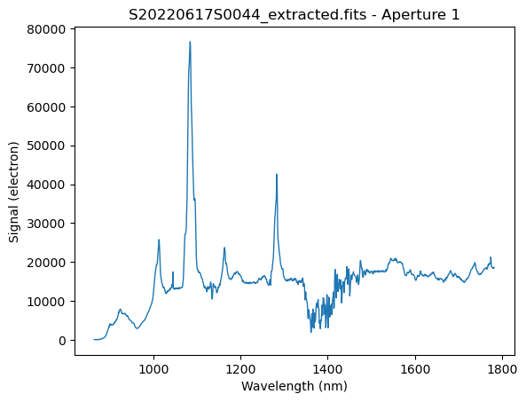

```python
plotter('S20220617S0044_extracted.fits')
```

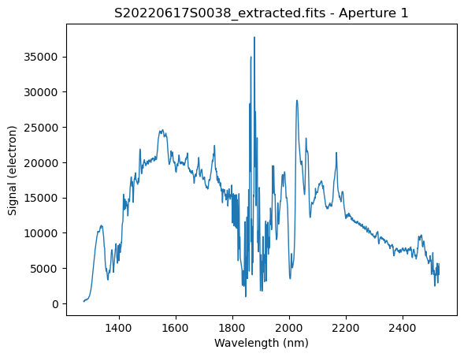

```python
plotter('S20220617S0038_extracted.fits')
```

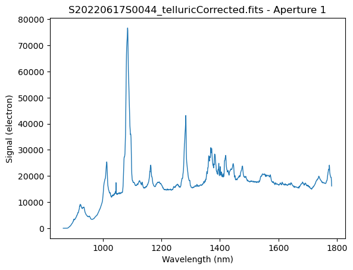

```python
plotter('S20220617S0044_telluricCorrected.fits')
```

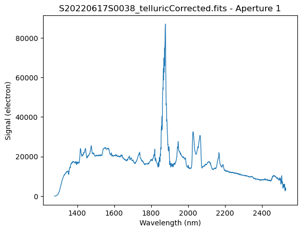

```python
plotter('S20220617S0038_telluricCorrected.fits')
```

# Display the final products

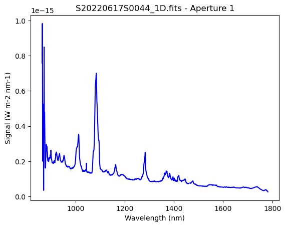

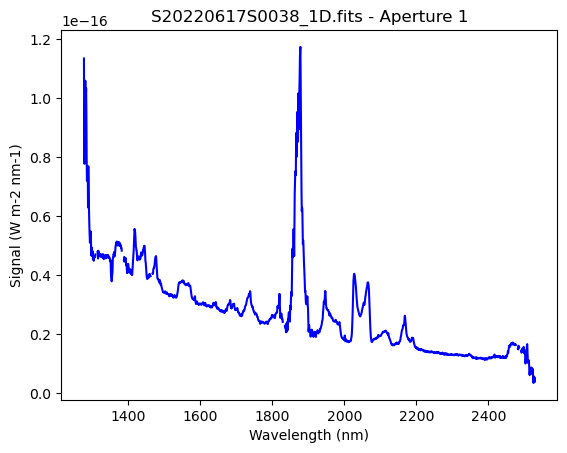

```python
ad = astrodata.open(reduce_scienceJH.output_filenames[0])
plotting.dgsplot_matplotlib(ad, 1, kwargs={})

ad = astrodata.open(reduce_scienceHK.output_filenames[0])
plotting.dgsplot_matplotlib(ad, 1, kwargs={})
```

# Join the two spectra

Be mindful, if you switch the order of the files, you might see a difference in the signal of the final product

```python
#Mask the extrema
###########################################################
reduce_maskedgesJH = Reduce()
reduce_maskedgesJH.files.append(reduce_scienceJH.output_filenames[0])
reduce_maskedgesJH.recipename = "maskBeyondRegions"
reduce_maskedgesJH.uparms = dict([('regions', "880:1720")])
reduce_maskedgesJH.runr()

reduce_maskedgesHK = Reduce()
reduce_maskedgesHK.files.append(reduce_scienceHK.output_filenames[0])
reduce_maskedgesHK.recipename = "maskBeyondRegions"
reduce_maskedgesHK.uparms = dict([('regions', "1400:2475")])
reduce_maskedgesHK.runr()
###########################################################

#Join the two spectra
reduce_join = Reduce()
reduce_join.files.append(reduce_maskedgesHK.output_filenames[0])
reduce_join.files.append(reduce_maskedgesJH.output_filenames[0])
reduce_join.recipename = "joinSpectra"
reduce_join.runr()
```

```
All submitted files appear valid:
S20220617S0044_1D.fits
WARNING - No recipe can be found in f2 recipe libs.
WARNING - Searching primitives ...
Found 'maskBeyondRegions' as a primitive.
================================================================================
RECIPE: maskBeyondRegions
================================================================================
   PRIMITIVE: maskBeyondRegions
   ----------------------------
   Masking pixels outside '880:1720' nm for aperture 1 of S20220617S0044_1D.fits
   .
	Wrote S20220617S0044_regionsMasked.fits in output directory
reduce completed successfully.
All submitted files appear valid:
S20220617S0038_1D.fits
WARNING - No recipe can be found in f2 recipe libs.
WARNING - Searching primitives ...
Found 'maskBeyondRegions' as a primitive.
================================================================================
RECIPE: maskBeyondRegions
================================================================================
   PRIMITIVE: maskBeyondRegions
   ----------------------------
   Masking pixels outside '1400:2475' nm for aperture 1 of S20220617S0038_1D.fits
   .
	Wrote S20220617S0038_regionsMasked.fits in output directory
reduce completed successfully.
All submitted files appear valid:
S20220617S0038_regionsMasked.fits ... S20220617S0044_regionsMasked.fits, 2 files submitted.
================================================================================
RECIPE: joinSpectra
================================================================================
   PRIMITIVE: resampleToCommonFrame
   --------------------------------
   WARNING - conserve is set to True but the units of S20220617S0038_regionsMasked.fits extension 1 are W / (nm m2)
   Resampling (with flux conservation) and linearizing S20220617S0038_regionsMasked.fits extension 1: w1=708.016 w2=2650.053 dw=0.650 npix=2990
   Array maps to [610:2989]
   WARNING - There are 0 NaN and 91 inf values in the data array. Setting to zero.
   WARNING - There are 0 NaN and 119 inf values in the variance array. Setting to zero.
```

[output cut: 29 more lines]

```
   Combining extension 1. Applying scale factors.
   S20220617S0038_align.fits                    1.000
   S20220617S0044_align.fits                    0.484

   Combining extension 2. Applying scale factors.
   S20220617S0038_align.fits                    1.000
   S20220617S0044_align.fits                    0.525

   Combining extension 3. Applying scale factors.
   S20220617S0038_align.fits                    1.000
   S20220617S0044_align.fits                    0.347

   .
	Wrote S20220617S0038_1Djoined.fits in output directory
reduce completed successfully.
```

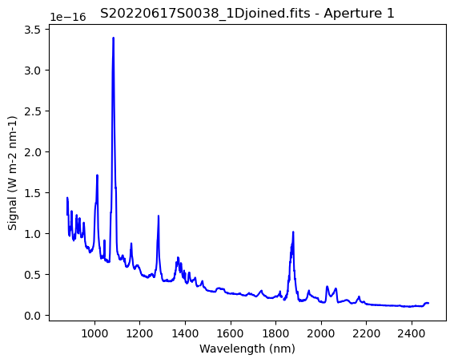

```python
ad = astrodata.open(reduce_join.output_filenames[0])
plotting.dgsplot_matplotlib(ad, 1, kwargs={})
```

# Clean up

```python
#clean_up(save_reduced=0)
```